# High School Seniors 2

### Validity

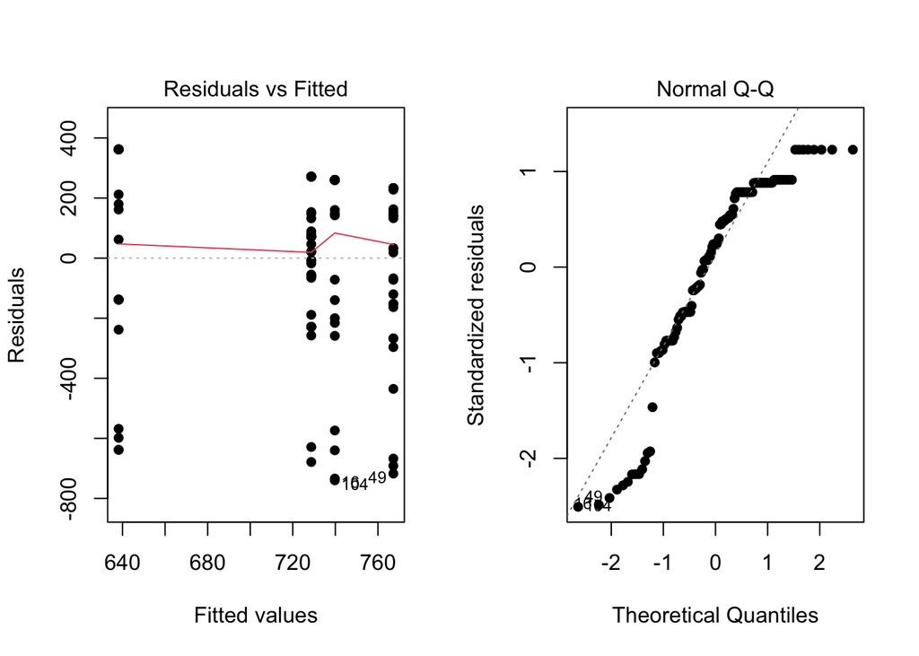

```r
par(mfrow=c(1,2))
plot(warp.aov, which=1:2, pch=16)
```

Even though we were unable to reject any of our null hypothesis, it is still important to check the validity of our data. It is strange that in our fitted plot there is a large gap. Despite this, the points seem to be mostly scatted in a random fashion. The Q-Q plot however, does not show a normal distribution of the residuals. This would lead us to reject the data either way.

### Final Interpretation

When running our statistical tests, there was not enough evidence to reject any of our three null hypothesi. With this we decide for now, that there is no relationship between any of our three variables. Even if our P-values had resulted as smaller, we still would not have had any viable evidence to prove anything since our data was not acceptable. I would recon however, that more data would prove our alternative hypothesis, since the means came out to be what we expected, with women and people from California having higher means in the importance they give to reducing pollution.